# Market Basket Analysis

Bhavesh Rajesh Talreja

#### First of all, we will use the python script on products.csv to generate the canonical transaction files for our analysis.

### Required library imports and reading data files.

```r
#clearing the existing data from the environment.
rm(list=ls())

library("arules")
library("arulesViz")

tr.1k  <- read.transactions("../data/tr-1k-canonical.csv" , sep=",")
tr.5k  <- read.transactions("../data/tr-5k-canonical.csv" , sep=",")
tr.20k <- read.transactions("../data/tr-20k-canonical.csv", sep=",")
tr.75k <- read.transactions("../data/tr-75k-canonical.csv", sep=",")

tr.1k
```

```
transactions in sparse format with
 1000 transactions (rows) and
 50 items (columns)
```

```r
tr.5k
```

```
transactions in sparse format with
 5000 transactions (rows) and
 50 items (columns)
```

```r
tr.20k
```

```
transactions in sparse format with
 20000 transactions (rows) and
 50 items (columns)
```

```r
tr.75k
```

```
transactions in sparse format with
 75000 transactions (rows) and
 50 items (columns)
```

### Frequent itemsets and Association rules mining.

```r
summary(tr.1k)
```

```
transactions as itemMatrix in sparse format with
 1000 rows (elements/itemsets/transactions) and
 50 columns (items) and a density of 0.07076

most frequent items:
Gongolais Cookie     Truffle Cake     Tuile Cookie       Berry Tart
             108              103              102               95
      Hot Coffee          (Other)
              94             3036

element (itemset/transaction) length distribution:
sizes
  1   2   3   4   5   6   7   8
 60 162 338 216 132  44  32  16

   Min. 1st Qu.  Median    Mean 3rd Qu.    Max.
  1.000   3.000   3.000   3.538   4.000   8.000

includes extended item information - examples:
```

|  | labels |
| --- | --- |
| 1 | Almond Bear Claw |
| 2 | Almond Croissant |
| 3 | Almond Tart |

```r
summary(tr.5k)
```

```
transactions as itemMatrix in sparse format with
 5000 rows (elements/itemsets/transactions) and
 50 columns (items) and a density of 0.07094

most frequent items:
   Coffee Eclair       Hot Coffee     Tuile Cookie  Strawberry Cake
             554              513              499              480
Gongolais Cookie          (Other)
             477            15212

element (itemset/transaction) length distribution:
sizes
   1    2    3    4    5    6    7    8
 248  923 1601 1144  596  237  148  103

   Min. 1st Qu.  Median    Mean 3rd Qu.    Max.
  1.000   3.000   3.000   3.547   4.000   8.000

includes extended item information - examples:
```

|  | labels |
| --- | --- |
| 1 | Almond Bear Claw |
| 2 | Almond Croissant |
| 3 | Almond Tart |

```r
summary(tr.20k)
```

```
transactions as itemMatrix in sparse format with
 20000 rows (elements/itemsets/transactions) and
 50 columns (items) and a density of 0.07113

most frequent items:
 Coffee Eclair     Hot Coffee   Tuile Cookie Apricot Danish
          2197           2072           1973           1854
  Orange Juice        (Other)
          1848          61186

element (itemset/transaction) length distribution:
sizes
   1    2    3    4    5    6    7    8
 934 3612 6570 4555 2305 1044  587  393

   Min. 1st Qu.  Median    Mean 3rd Qu.    Max.
  1.000   3.000   3.000   3.557   4.000   8.000

includes extended item information - examples:
```

|  | labels |
| --- | --- |
| 1 | Almond Bear Claw |
| 2 | Almond Croissant |
| 3 | Almond Tart |

```r
summary(tr.75k)
```

```
transactions as itemMatrix in sparse format with
 75000 rows (elements/itemsets/transactions) and
 50 columns (items) and a density of 0.07098907

most frequent items:
  Coffee Eclair      Hot Coffee    Tuile Cookie     Cherry Tart
           8193            7700            7556            6987
Strawberry Cake         (Other)
           6948          228825

element (itemset/transaction) length distribution:
sizes
    1     2     3     4     5     6     7     8
 3592 13579 24674 17003  8640  3840  2191  1481

   Min. 1st Qu.  Median    Mean 3rd Qu.    Max.
  1.000   3.000   3.000   3.549   4.000   8.000

includes extended item information - examples:
```

|  | labels |
| --- | --- |
| 1 | Almond Bear Claw |
| 2 | Almond Croissant |
| 3 | Almond Tart |

```r
#COMMENT: As observed, minimum support is 0.1 and minimum confidence is 0.8.
# We can try multiple values for support to observe and analyze:
# The support value of 0.001 took immeasurable time to run. so, we will try with 0.01.
# The confidence value of 0.9 to find good association rules.

# Frequent Itemsets for all transaction datasets.
# Inspect shows the required output i.e. All items in it described by the product name and along with it, the support of that itemset.

freq_IS_1k <- apriori(tr.1k, parameter=list(support=0.01,target="frequent itemsets"))
```

```
Apriori

Parameter specification:
```

|  | confidence | minval | smax | arem | aval | originalSupport | maxtime | support | minlen | maxlen | target | ext |
| --- | --- | --- | --- | --- | --- | --- | --- | --- | --- | --- | --- | --- |
|  | NA | 0.1 | 1 | none | FALSE | TRUE | 5 | 0.01 | 1 | 10 | frequent itemsets | TRUE |

```
Algorithmic control:
```

|  | filter | tree | heap | memopt | load | sort | verbose |
| --- | --- | --- | --- | --- | --- | --- | --- |
|  | 0.1 | TRUE | TRUE | FALSE | TRUE | 2 | TRUE |

```
Absolute minimum support count: 10

set item appearances ...[0 item(s)] done [0.00s].
set transactions ...[50 item(s), 1000 transaction(s)] done [0.00s].
sorting and recoding items ... [50 item(s)] done [0.00s].
creating transaction tree ... done [0.00s].
checking subsets of size 1 2 3 4 5 done [0.00s].
sorting transactions ... done [0.00s].
writing ... [132 set(s)] done [0.00s].
creating S4 object  ... done [0.00s].
```

```r
inspect(sort(freq_IS_1k, decreasing=T, by="count"))
```

```
      items                  support count
[1]   {Gongolais Cookie}       0.108   108
[2]   {Truffle Cake}           0.103   103
[3]   {Tuile Cookie}           0.102   102
[4]   {Berry Tart}             0.095    95
[5]   {Hot Coffee}             0.094    94
[6]   {Coffee Eclair}          0.093    93
[7]   {Strawberry Cake}        0.091    91
[8]   {Apple Croissant}        0.091    91
[9]   {Marzipan Cookie}        0.090    90
[10]  {Napoleon Cake}          0.090    90
[11]  {Lemon Cake}             0.085    85
[12]  {Chocolate Coffee}       0.085    85
[13]  {Chocolate Cake}         0.084    84
[14]  {Cherry Tart}            0.084    84
[15]  {Apple Danish}           0.084    84
[16]  {Orange Juice}           0.082    82
[17]  {Raspberry Cookie}       0.082    82
[18]  {Blueberry Tart}         0.081    81
[19]  {Apple Tart}             0.079    79
[20]  {Opera Cake}             0.078    78
[21]  {Cheese Croissant}       0.078    78
[22]  {Bottled Water}          0.077    77
[23]  {Cherry Soda}            0.077    77
[24]  {Lemon Tart}             0.076    76
[25]  {Apricot Croissant}      0.076    76
[26]  {Apricot Danish}         0.075    75
[27]  {Vanilla Frappuccino}    0.074    74
[28]  {Blackberry Tart}        0.073    73
[29]  {Casino Cake}            0.072    72
[30]  {Raspberry Lemonade}     0.072    72
[31]  {Apple Pie}              0.068    68
[32]  {Lemon Lemonade}         0.066    66
[33]  {Lemon Cookie}           0.066    66
[34]  {Almond Twist}           0.065    65
[35]  {Green Tea}              0.062    62
[36]  {Walnut Cookie}          0.061    61
[37]  {Single Espresso}        0.059    59
[38]  {Gongolais Cookie,
       Truffle Cake}           0.058    58
```

[output cut: 200 more lines]

```
       Truffle Cake}           0.013    13
[126] {Berry Tart,
       Gongolais Cookie}       0.012    12
[127] {Orange Juice,
       Raspberry Cookie}       0.011    11
[128] {Apricot Tart,
       Napoleon Cake}          0.010    10
[129] {Orange Juice,
       Truffle Cake}           0.010    10
[130] {Cheese Croissant,
       Raspberry Cookie}       0.010    10
[131] {Hot Coffee,
       Napoleon Cake}          0.010    10
[132] {Apple Croissant,
       Truffle Cake}           0.010    10
```

```r
freq_IS_5k <- apriori(tr.5k, parameter=list(support=0.01,target="frequent itemsets"))
```

```
Apriori

Parameter specification:
```

|  | confidence | minval | smax | arem | aval | originalSupport | maxtime | support | minlen | maxlen | target | ext |
| --- | --- | --- | --- | --- | --- | --- | --- | --- | --- | --- | --- | --- |
|  | NA | 0.1 | 1 | none | FALSE | TRUE | 5 | 0.01 | 1 | 10 | frequent itemsets | TRUE |

```
Algorithmic control:
```

|  | filter | tree | heap | memopt | load | sort | verbose |
| --- | --- | --- | --- | --- | --- | --- | --- |
|  | 0.1 | TRUE | TRUE | FALSE | TRUE | 2 | TRUE |

```
Absolute minimum support count: 50

set item appearances ...[0 item(s)] done [0.00s].
set transactions ...[50 item(s), 5000 transaction(s)] done [0.00s].
sorting and recoding items ... [50 item(s)] done [0.00s].
creating transaction tree ... done [0.00s].
checking subsets of size 1 2 3 4 5 done [0.00s].
sorting transactions ... done [0.00s].
writing ... [124 set(s)] done [0.00s].
creating S4 object  ... done [0.00s].
```

```r
inspect(sort(freq_IS_5k, decreasing=T, by="count"))
```

```
      items                  support count
[1]   {Coffee Eclair}         0.1108   554
[2]   {Hot Coffee}            0.1026   513
[3]   {Tuile Cookie}          0.0998   499
[4]   {Strawberry Cake}       0.0960   480
[5]   {Gongolais Cookie}      0.0954   477
[6]   {Orange Juice}          0.0922   461
[7]   {Cherry Tart}           0.0920   460
[8]   {Apricot Danish}        0.0892   446
[9]   {Truffle Cake}          0.0876   438
[10]  {Blueberry Tart}        0.0852   426
[11]  {Lemon Cake}            0.0850   425
[12]  {Marzipan Cookie}       0.0836   418
[13]  {Opera Cake}            0.0836   418
[14]  {Apricot Croissant}     0.0822   411
[15]  {Napoleon Cake}         0.0818   409
[16]  {Almond Twist}          0.0814   407
[17]  {Chocolate Coffee}      0.0808   404
[18]  {Chocolate Cake}        0.0798   399
[19]  {Berry Tart}            0.0782   391
[20]  {Apple Danish}          0.0782   391
[21]  {Apple Pie}             0.0782   391
[22]  {Bottled Water}         0.0772   386
[23]  {Cheese Croissant}      0.0770   385
[24]  {Chocolate Tart}        0.0762   381
[25]  {Blackberry Tart}       0.0760   380
[26]  {Casino Cake}           0.0746   373
[27]  {Apple Croissant}       0.0742   371
[28]  {Vanilla Frappuccino}   0.0734   367
[29]  {Apple Tart}            0.0734   367
[30]  {Lemon Tart}            0.0708   354
[31]  {Walnut Cookie}         0.0706   353
[32]  {Raspberry Lemonade}    0.0678   339
[33]  {Cherry Soda}           0.0670   335
[34]  {Single Espresso}       0.0654   327
[35]  {Lemon Lemonade}        0.0648   324
[36]  {Lemon Cookie}          0.0642   321
[37]  {Raspberry Cookie}      0.0640   320
[38]  {Green Tea}             0.0620   310
[39]  {Apricot Danish,
```

[output cut: 184 more lines]

```
       Raspberry Cookie,
       Raspberry Lemonade}    0.0212   106
[122] {Green Tea,
       Lemon Cookie,
       Lemon Lemonade,
       Raspberry Lemonade}    0.0212   106
[123] {Green Tea,
       Lemon Cookie,
       Raspberry Cookie,
       Raspberry Lemonade}    0.0212   106
[124] {Green Tea,
       Lemon Cookie,
       Lemon Lemonade,
       Raspberry Cookie,
       Raspberry Lemonade}    0.0212   106
```

```r
freq_IS_20k <- apriori(tr.20k, parameter=list(support=0.01,target="frequent itemsets"))
```

```
Apriori

Parameter specification:
```

|  | confidence | minval | smax | arem | aval | originalSupport | maxtime | support | minlen | maxlen | target | ext |
| --- | --- | --- | --- | --- | --- | --- | --- | --- | --- | --- | --- | --- |
|  | NA | 0.1 | 1 | none | FALSE | TRUE | 5 | 0.01 | 1 | 10 | frequent itemsets | TRUE |

```
Algorithmic control:
```

|  | filter | tree | heap | memopt | load | sort | verbose |
| --- | --- | --- | --- | --- | --- | --- | --- |
|  | 0.1 | TRUE | TRUE | FALSE | TRUE | 2 | TRUE |

```
Absolute minimum support count: 200

set item appearances ...[0 item(s)] done [0.00s].
set transactions ...[50 item(s), 20000 transaction(s)] done [0.01s].
sorting and recoding items ... [50 item(s)] done [0.00s].
creating transaction tree ... done [0.01s].
checking subsets of size 1 2 3 4 5 done [0.00s].
sorting transactions ... done [0.01s].
writing ... [124 set(s)] done [0.00s].
creating S4 object  ... done [0.00s].
```

```r
inspect(sort(freq_IS_20k, decreasing=T, by="count"))
```

```
      items                  support count
[1]   {Coffee Eclair}        0.10985  2197
[2]   {Hot Coffee}           0.10360  2072
[3]   {Tuile Cookie}         0.09865  1973
[4]   {Apricot Danish}       0.09270  1854
[5]   {Orange Juice}         0.09240  1848
[6]   {Strawberry Cake}      0.09200  1840
[7]   {Gongolais Cookie}     0.09185  1837
[8]   {Cherry Tart}          0.09125  1825
[9]   {Marzipan Cookie}      0.08645  1729
[10]  {Lemon Cake}           0.08600  1720
[11]  {Truffle Cake}         0.08465  1693
[12]  {Napoleon Cake}        0.08450  1690
[13]  {Berry Tart}           0.08430  1686
[14]  {Blueberry Tart}       0.08390  1678
[15]  {Chocolate Cake}       0.08365  1673
[16]  {Opera Cake}           0.08365  1673
[17]  {Chocolate Coffee}     0.08225  1645
[18]  {Cheese Croissant}     0.08170  1634
[19]  {Apricot Croissant}    0.08170  1634
[20]  {Vanilla Frappuccino}  0.07675  1535
[21]  {Blackberry Tart}      0.07670  1534
[22]  {Chocolate Tart}       0.07635  1527
[23]  {Lemon Tart}           0.07595  1519
[24]  {Casino Cake}          0.07530  1506
[25]  {Apple Pie}            0.07415  1483
[26]  {Almond Twist}         0.07315  1463
[27]  {Bottled Water}        0.07215  1443
[28]  {Single Espresso}      0.07110  1422
[29]  {Apple Croissant}      0.07100  1420
[30]  {Walnut Cookie}        0.06950  1390
[31]  {Raspberry Cookie}     0.06945  1389
[32]  {Apple Tart}           0.06925  1385
[33]  {Raspberry Lemonade}   0.06845  1369
[34]  {Lemon Cookie}         0.06825  1365
[35]  {Apple Danish}         0.06755  1351
[36]  {Lemon Lemonade}       0.06655  1331
[37]  {Cherry Soda}          0.06530  1306
[38]  {Green Tea}            0.06215  1243
[39]  {Apricot Danish,
```

[output cut: 184 more lines]

```
       Raspberry Cookie,
       Raspberry Lemonade}   0.02045   409
[122] {Green Tea,
       Lemon Cookie,
       Lemon Lemonade,
       Raspberry Cookie}     0.02040   408
[123] {Green Tea,
       Lemon Cookie,
       Raspberry Cookie,
       Raspberry Lemonade}   0.02040   408
[124] {Green Tea,
       Lemon Cookie,
       Lemon Lemonade,
       Raspberry Cookie,
       Raspberry Lemonade}   0.02040   408
```

```r
freq_IS_75k <- apriori(tr.75k, parameter=list(support=0.01,target="frequent itemsets"))
```

```
Apriori

Parameter specification:
```

|  | confidence | minval | smax | arem | aval | originalSupport | maxtime | support | minlen | maxlen | target | ext |
| --- | --- | --- | --- | --- | --- | --- | --- | --- | --- | --- | --- | --- |
|  | NA | 0.1 | 1 | none | FALSE | TRUE | 5 | 0.01 | 1 | 10 | frequent itemsets | TRUE |

```
Algorithmic control:
```

|  | filter | tree | heap | memopt | load | sort | verbose |
| --- | --- | --- | --- | --- | --- | --- | --- |
|  | 0.1 | TRUE | TRUE | FALSE | TRUE | 2 | TRUE |

```
Absolute minimum support count: 750

set item appearances ...[0 item(s)] done [0.00s].
set transactions ...[50 item(s), 75000 transaction(s)] done [0.02s].
sorting and recoding items ... [50 item(s)] done [0.00s].
creating transaction tree ... done [0.02s].
checking subsets of size 1 2 3 4 5 done [0.01s].
sorting transactions ... done [0.01s].
writing ... [124 set(s)] done [0.00s].
creating S4 object  ... done [0.01s].
```

```r
inspect(sort(freq_IS_75k, decreasing=T, by="count"))
```

```
      items                     support count
[1]   {Coffee Eclair}        0.10924000  8193
[2]   {Hot Coffee}           0.10266667  7700
[3]   {Tuile Cookie}         0.10074667  7556
[4]   {Cherry Tart}          0.09316000  6987
[5]   {Strawberry Cake}      0.09264000  6948
[6]   {Apricot Danish}       0.09257333  6943
[7]   {Orange Juice}         0.09161333  6871
[8]   {Gongolais Cookie}     0.09044000  6783
[9]   {Marzipan Cookie}      0.08977333  6733
[10]  {Berry Tart}           0.08482667  6362
[11]  {Apricot Croissant}    0.08398667  6299
[12]  {Lemon Cake}           0.08361333  6271
[13]  {Chocolate Cake}       0.08353333  6265
[14]  {Chocolate Coffee}     0.08314667  6236
[15]  {Blueberry Tart}       0.08294667  6221
[16]  {Napoleon Cake}        0.08274667  6206
[17]  {Truffle Cake}         0.08224000  6168
[18]  {Cheese Croissant}     0.08221333  6166
[19]  {Opera Cake}           0.08209333  6157
[20]  {Vanilla Frappuccino}  0.07746667  5810
[21]  {Almond Twist}         0.07720000  5790
[22]  {Apple Pie}            0.07712000  5784
[23]  {Blackberry Tart}      0.07586667  5690
[24]  {Lemon Tart}           0.07580000  5685
[25]  {Bottled Water}        0.07520000  5640
[26]  {Casino Cake}          0.07501333  5626
[27]  {Chocolate Tart}       0.07372000  5529
[28]  {Lemon Lemonade}       0.06824000  5118
[29]  {Apple Tart}           0.06822667  5117
[30]  {Lemon Cookie}         0.06801333  5101
[31]  {Single Espresso}      0.06797333  5098
[32]  {Walnut Cookie}        0.06785333  5089
[33]  {Raspberry Lemonade}   0.06774667  5081
[34]  {Apple Danish}         0.06769333  5077
[35]  {Raspberry Cookie}     0.06764000  5073
[36]  {Apple Croissant}      0.06729333  5047
[37]  {Green Tea}            0.06246667  4685
[38]  {Cherry Soda}          0.06198667  4649
[39]  {Apricot Danish,
```

[output cut: 184 more lines]

```
       Lemon Lemonade,
       Raspberry Cookie}     0.02073333  1555
[122] {Green Tea,
       Lemon Cookie,
       Lemon Lemonade,
       Raspberry Lemonade}   0.02073333  1555
[123] {Green Tea,
       Lemon Cookie,
       Lemon Lemonade,
       Raspberry Cookie,
       Raspberry Lemonade}   0.02073333  1555
[124] {Apple Croissant,
       Apple Danish,
       Apple Tart,
       Cherry Soda}          0.02058667  1544
```

```r
#Association Rules mining for all transaction datasets. Inspect shows the required output i.e. for each rule: the antecedent, the consequent, the support of the rule, the confidence of the rule.
rules_1k <- apriori(tr.1k, parameter=list(support=0.01,confidence=0.9))
```

```
Apriori

Parameter specification:
```

|  | confidence | minval | smax | arem | aval | originalSupport | maxtime | support | minlen | maxlen | target | ext |
| --- | --- | --- | --- | --- | --- | --- | --- | --- | --- | --- | --- | --- |
|  | 0.9 | 0.1 | 1 | none | FALSE | TRUE | 5 | 0.01 | 1 | 10 | rules | TRUE |

```
Algorithmic control:
```

|  | filter | tree | heap | memopt | load | sort | verbose |
| --- | --- | --- | --- | --- | --- | --- | --- |
|  | 0.1 | TRUE | TRUE | FALSE | TRUE | 2 | TRUE |

```
Absolute minimum support count: 10

set item appearances ...[0 item(s)] done [0.00s].
set transactions ...[50 item(s), 1000 transaction(s)] done [0.00s].
sorting and recoding items ... [50 item(s)] done [0.00s].
creating transaction tree ... done [0.00s].
checking subsets of size 1 2 3 4 5 done [0.00s].
writing ... [68 rule(s)] done [0.00s].
creating S4 object  ... done [0.00s].
```

```r
summary(rules_1k)
```

```
set of 68 rules

rule length distribution (lhs + rhs):sizes
 3  4  5
42 22  4

   Min. 1st Qu.  Median    Mean 3rd Qu.    Max.
  3.000   3.000   3.000   3.441   4.000   5.000

summary of quality measures:
    support          confidence        coverage            lift
 Min.   :0.01800   Min.   :0.9000   Min.   :0.01800   Min.   :10.01
 1st Qu.:0.01900   1st Qu.:0.9394   1st Qu.:0.01900   1st Qu.:11.87
 Median :0.02400   Median :0.9661   Median :0.02550   Median :13.16
 Mean   :0.02538   Mean   :0.9661   Mean   :0.02637   Mean   :13.10
 3rd Qu.:0.02900   3rd Qu.:1.0000   3rd Qu.:0.03100   3rd Qu.:14.39
 Max.   :0.04000   Max.   :1.0000   Max.   :0.04400   Max.   :19.61
     count
 Min.   :18.00
 1st Qu.:19.00
 Median :24.00
 Mean   :25.38
 3rd Qu.:29.00
 Max.   :40.00

mining info:
```

|  | data | ntransactions | support | confidence | call |
| --- | --- | --- | --- | --- | --- |
|  | tr.1k | 1000 | 0.01 | 0.9 | apriori(data = tr.1k, parameter = list(support = 0.01, confidence = 0.9)) |

```r
inspect(sort(rules_1k, decreasing=T, by="confidence"))
```

```
     lhs                       rhs                   support confidence coverage     lift count
[1]  {Chocolate Tart,
      Walnut Cookie}        => {Vanilla Frappuccino}   0.018  1.0000000    0.018 13.51351    18
[2]  {Vanilla Frappuccino,
      Walnut Cookie}        => {Chocolate Tart}        0.018  1.0000000    0.018 19.60784    18
[3]  {Apricot Croissant,
      Hot Coffee}           => {Blueberry Tart}        0.032  1.0000000    0.032 12.34568    32
[4]  {Raspberry Cookie,
      Raspberry Lemonade}   => {Lemon Cookie}          0.029  1.0000000    0.029 15.15152    29
[5]  {Green Tea,
      Lemon Cookie,
      Lemon Lemonade}       => {Raspberry Lemonade}    0.019  1.0000000    0.019 13.88889    19
[6]  {Green Tea,
      Lemon Lemonade,
      Raspberry Lemonade}   => {Lemon Cookie}          0.019  1.0000000    0.019 15.15152    19
[7]  {Green Tea,
      Lemon Cookie,
      Raspberry Lemonade}   => {Lemon Lemonade}        0.019  1.0000000    0.019 15.15152    19
[8]  {Green Tea,
      Lemon Cookie,
      Lemon Lemonade}       => {Raspberry Cookie}      0.019  1.0000000    0.019 12.19512    19
[9]  {Green Tea,
      Lemon Lemonade,
      Raspberry Cookie}     => {Lemon Cookie}          0.019  1.0000000    0.019 15.15152    19
[10] {Green Tea,
      Lemon Cookie,
      Raspberry Cookie}     => {Lemon Lemonade}        0.019  1.0000000    0.019 15.15152    19
[11] {Green Tea,
      Lemon Lemonade,
      Raspberry Lemonade}   => {Raspberry Cookie}      0.019  1.0000000    0.019 12.19512    19
[12] {Green Tea,
      Lemon Lemonade,
      Raspberry Cookie}     => {Raspberry Lemonade}    0.019  1.0000000    0.019 13.88889    19
[13] {Green Tea,
      Raspberry Cookie,
      Raspberry Lemonade}   => {Lemon Lemonade}        0.019  1.0000000    0.019 15.15152    19
[14] {Lemon Cookie,
      Lemon Lemonade,
      Raspberry Lemonade}   => {Raspberry Cookie}      0.028  1.0000000    0.028 12.19512    28
[15] {Lemon Cookie,
```

[output cut: 112 more lines]

```
      Lemon Lemonade}       => {Lemon Cookie}          0.019  0.9047619    0.021 13.70851    19
[62] {Green Tea,
      Lemon Lemonade}       => {Raspberry Lemonade}    0.019  0.9047619    0.021 12.56614    19
[63] {Green Tea,
      Lemon Lemonade}       => {Raspberry Cookie}      0.019  0.9047619    0.021 11.03368    19
[64] {Lemon Cookie,
      Lemon Lemonade}       => {Raspberry Lemonade}    0.028  0.9032258    0.031 12.54480    28
[65] {Lemon Cookie,
      Lemon Lemonade}       => {Raspberry Cookie}      0.028  0.9032258    0.031 11.01495    28
[66] {Lemon Lemonade,
      Raspberry Cookie}     => {Lemon Cookie}          0.028  0.9032258    0.031 13.68524    28
[67] {Lemon Lemonade,
      Raspberry Cookie}     => {Raspberry Lemonade}    0.028  0.9032258    0.031 12.54480    28
[68] {Almond Twist,
      Coffee Eclair}        => {Apple Pie}             0.027  0.9000000    0.030 13.23529    27
```

```r
rules_5k <- apriori(tr.5k, parameter=list(support=0.01,confidence=0.9))
```

```
Apriori

Parameter specification:
```

|  | confidence | minval | smax | arem | aval | originalSupport | maxtime | support | minlen | maxlen | target | ext |
| --- | --- | --- | --- | --- | --- | --- | --- | --- | --- | --- | --- | --- |
|  | 0.9 | 0.1 | 1 | none | FALSE | TRUE | 5 | 0.01 | 1 | 10 | rules | TRUE |

```
Algorithmic control:
```

|  | filter | tree | heap | memopt | load | sort | verbose |
| --- | --- | --- | --- | --- | --- | --- | --- |
|  | 0.1 | TRUE | TRUE | FALSE | TRUE | 2 | TRUE |

```
Absolute minimum support count: 50

set item appearances ...[0 item(s)] done [0.00s].
set transactions ...[50 item(s), 5000 transaction(s)] done [0.00s].
sorting and recoding items ... [50 item(s)] done [0.00s].
creating transaction tree ... done [0.00s].
checking subsets of size 1 2 3 4 5 done [0.00s].
writing ... [70 rule(s)] done [0.00s].
creating S4 object  ... done [0.00s].
```

```r
summary(rules_5k)
```

```
set of 70 rules

rule length distribution (lhs + rhs):sizes
 3  4  5
44 22  4

   Min. 1st Qu.  Median    Mean 3rd Qu.    Max.
  3.000   3.000   3.000   3.429   4.000   5.000

summary of quality measures:
    support          confidence        coverage            lift
 Min.   :0.02120   Min.   :0.9017   Min.   :0.02120   Min.   : 8.22
 1st Qu.:0.02120   1st Qu.:0.9167   1st Qu.:0.02300   1st Qu.:11.91
 Median :0.02620   Median :0.9425   Median :0.02780   Median :13.75
 Mean   :0.02636   Mean   :0.9524   Mean   :0.02778   Mean   :13.25
 3rd Qu.:0.03055   3rd Qu.:0.9981   3rd Qu.:0.03155   3rd Qu.:14.74
 Max.   :0.04080   Max.   :1.0000   Max.   :0.04360   Max.   :15.62
     count
 Min.   :106.0
 1st Qu.:106.0
 Median :131.0
 Mean   :131.8
 3rd Qu.:152.8
 Max.   :204.0

mining info:
```

|  | data | ntransactions | support | confidence | call |
| --- | --- | --- | --- | --- | --- |
|  | tr.5k | 5000 | 0.01 | 0.9 | apriori(data = tr.5k, parameter = list(support = 0.01, confidence = 0.9)) |

```r
inspect(sort(rules_5k, decreasing=T, by="confidence"))
```

```
     lhs                     rhs                   support confidence coverage      lift count
[1]  {Apple Danish,
      Apple Tart,
      Cherry Soda}        => {Apple Croissant}      0.0228  1.0000000   0.0228 13.477089   114
[2]  {Green Tea,
      Lemon Lemonade,
      Raspberry Cookie}   => {Lemon Cookie}         0.0212  1.0000000   0.0212 15.576324   106
[3]  {Green Tea,
      Lemon Lemonade,
      Raspberry Cookie}   => {Raspberry Lemonade}   0.0212  1.0000000   0.0212 14.749263   106
[4]  {Green Tea,
      Lemon Lemonade,
      Raspberry Lemonade} => {Raspberry Cookie}     0.0212  1.0000000   0.0212 15.625000   106
[5]  {Green Tea,
      Raspberry Cookie,
      Raspberry Lemonade} => {Lemon Lemonade}       0.0212  1.0000000   0.0212 15.432099   106
[6]  {Green Tea,
      Lemon Lemonade,
      Raspberry Lemonade} => {Lemon Cookie}         0.0212  1.0000000   0.0212 15.576324   106
[7]  {Green Tea,
      Lemon Cookie,
      Raspberry Lemonade} => {Lemon Lemonade}       0.0212  1.0000000   0.0212 15.432099   106
[8]  {Green Tea,
      Raspberry Cookie,
      Raspberry Lemonade} => {Lemon Cookie}         0.0212  1.0000000   0.0212 15.576324   106
[9]  {Green Tea,
      Lemon Cookie,
      Raspberry Lemonade} => {Raspberry Cookie}     0.0212  1.0000000   0.0212 15.625000   106
[10] {Lemon Lemonade,
      Raspberry Cookie,
      Raspberry Lemonade} => {Lemon Cookie}         0.0262  1.0000000   0.0262 15.576324   131
[11] {Lemon Cookie,
      Raspberry Cookie,
      Raspberry Lemonade} => {Lemon Lemonade}       0.0262  1.0000000   0.0262 15.432099   131
[12] {Almond Twist,
      Apple Pie,
      Hot Coffee}         => {Coffee Eclair}        0.0308  1.0000000   0.0308  9.025271   154
[13] {Apple Pie,
      Coffee Eclair,
      Hot Coffee}         => {Almond Twist}         0.0308  1.0000000   0.0308 12.285012   154
```

[output cut: 116 more lines]

```
      Chocolate Cake}     => {Chocolate Coffee}     0.0312  0.9122807   0.0342 11.290603   156
[64] {Apple Danish,
      Cherry Soda}        => {Apple Tart}           0.0228  0.9120000   0.0250 12.425068   114
[65] {Coffee Eclair,
      Hot Coffee}         => {Apple Pie}            0.0308  0.9112426   0.0338 11.652719   154
[66] {Coffee Eclair,
      Hot Coffee}         => {Almond Twist}         0.0308  0.9112426   0.0338 11.194627   154
[67] {Blackberry Tart,
      Single Espresso}    => {Coffee Eclair}        0.0286  0.9108280   0.0314  8.220470   143
[68] {Apple Tart,
      Cherry Soda}        => {Apple Croissant}      0.0230  0.9055118   0.0254 12.203663   115
[69] {Apple Croissant,
      Apple Danish}       => {Apple Tart}           0.0298  0.9030303   0.0330 12.302865   149
[70] {Casino Cake,
      Chocolate Coffee}   => {Chocolate Cake}       0.0312  0.9017341   0.0346 11.299926   156
```

```r
rules_20k <- apriori(tr.20k, parameter=list(support=0.01,confidence=0.9))
```

```
Apriori

Parameter specification:
```

|  | confidence | minval | smax | arem | aval | originalSupport | maxtime | support | minlen | maxlen | target | ext |
| --- | --- | --- | --- | --- | --- | --- | --- | --- | --- | --- | --- | --- |
|  | 0.9 | 0.1 | 1 | none | FALSE | TRUE | 5 | 0.01 | 1 | 10 | rules | TRUE |

```
Algorithmic control:
```

|  | filter | tree | heap | memopt | load | sort | verbose |
| --- | --- | --- | --- | --- | --- | --- | --- |
|  | 0.1 | TRUE | TRUE | FALSE | TRUE | 2 | TRUE |

```
Absolute minimum support count: 200

set item appearances ...[0 item(s)] done [0.00s].
set transactions ...[50 item(s), 20000 transaction(s)] done [0.01s].
sorting and recoding items ... [50 item(s)] done [0.00s].
creating transaction tree ... done [0.00s].
checking subsets of size 1 2 3 4 5 done [0.00s].
writing ... [70 rule(s)] done [0.00s].
creating S4 object  ... done [0.00s].
```

```r
summary(rules_20k)
```

```
set of 70 rules

rule length distribution (lhs + rhs):sizes
 3  4  5
44 22  4

   Min. 1st Qu.  Median    Mean 3rd Qu.    Max.
  3.000   3.000   3.000   3.429   4.000   5.000

summary of quality measures:
    support          confidence        coverage            lift
 Min.   :0.02040   Min.   :0.9014   Min.   :0.02040   Min.   : 8.307
 1st Qu.:0.02051   1st Qu.:0.9173   1st Qu.:0.02117   1st Qu.:12.763
 Median :0.02545   Median :0.9270   Median :0.02558   Median :13.472
 Mean   :0.02477   Mean   :0.9489   Mean   :0.02619   Mean   :13.191
 3rd Qu.:0.02781   3rd Qu.:0.9929   3rd Qu.:0.02855   3rd Qu.:14.325
 Max.   :0.04100   Max.   :1.0000   Max.   :0.04365   Max.   :15.026
     count
 Min.   :408.0
 1st Qu.:410.2
 Median :509.0
 Mean   :495.4
 3rd Qu.:556.2
 Max.   :820.0

mining info:
```

|  | data | ntransactions | support | confidence | call |
| --- | --- | --- | --- | --- | --- |
|  | tr.20k | 20000 | 0.01 | 0.9 | apriori(data = tr.20k, parameter = list(support = 0.01, confidence = 0.9)) |

```r
inspect(sort(rules_20k, decreasing=T, by="confidence"))
```

```
     lhs                       rhs                   support confidence coverage      lift count
[1]  {Green Tea,
      Lemon Cookie,
      Lemon Lemonade,
      Raspberry Cookie}     => {Raspberry Lemonade}  0.02040  1.0000000  0.02040 14.609204   408
[2]  {Green Tea,
      Lemon Cookie,
      Raspberry Cookie,
      Raspberry Lemonade}   => {Lemon Lemonade}      0.02040  1.0000000  0.02040 15.026296   408
[3]  {Almond Twist,
      Coffee Eclair,
      Hot Coffee}           => {Apple Pie}           0.02810  0.9982238  0.02815 13.462223   562
[4]  {Green Tea,
      Raspberry Cookie,
      Raspberry Lemonade}   => {Lemon Lemonade}      0.02045  0.9975610  0.02050 14.989647   409
[5]  {Green Tea,
      Lemon Cookie,
      Lemon Lemonade,
      Raspberry Lemonade}   => {Raspberry Cookie}    0.02040  0.9975550  0.02045 14.363643   408
[6]  {Green Tea,
      Lemon Lemonade,
      Raspberry Cookie,
      Raspberry Lemonade}   => {Lemon Cookie}        0.02040  0.9975550  0.02045 14.616191   408
[7]  {Apple Pie,
      Coffee Eclair,
      Hot Coffee}           => {Almond Twist}        0.02810  0.9964539  0.02820 13.622063   562
[8]  {Lemon Cookie,
      Lemon Lemonade,
      Raspberry Cookie}     => {Raspberry Lemonade}  0.02545  0.9960861  0.02555 14.552025   509
[9]  {Apple Danish,
      Apple Tart,
      Cherry Soda}          => {Apple Croissant}     0.02100  0.9952607  0.02110 14.017756   420
[10] {Green Tea,
      Lemon Lemonade,
      Raspberry Lemonade}   => {Lemon Cookie}        0.02045  0.9951338  0.02055 14.580715   409
[11] {Green Tea,
      Lemon Cookie,
      Lemon Lemonade}       => {Raspberry Lemonade}  0.02045  0.9951338  0.02055 14.538113   409
[12] {Green Tea,
      Lemon Cookie,
```

[output cut: 116 more lines]

```
      Raspberry Cookie}     => {Lemon Lemonade}      0.02065  0.9116998  0.02265 13.699471   413
[64] {Apple Croissant,
      Apple Danish}         => {Apple Tart}          0.02600  0.9090909  0.02860 13.127667   520
[65] {Green Tea,
      Raspberry Cookie}     => {Lemon Cookie}        0.02055  0.9072848  0.02265 13.293550   411
[66] {Green Tea,
      Raspberry Cookie}     => {Raspberry Lemonade}  0.02050  0.9050773  0.02265 13.222458   410
[67] {Apple Croissant,
      Apple Tart}           => {Apple Danish}        0.02600  0.9043478  0.02875 13.387829   520
[68] {Apple Danish,
      Cherry Soda}          => {Apple Croissant}     0.02125  0.9023355  0.02355 12.708950   425
[69] {Lemon Cookie,
      Raspberry Lemonade}   => {Lemon Lemonade}      0.02560  0.9014085  0.02840 13.544830   512
[70] {Lemon Cookie,
      Raspberry Lemonade}   => {Raspberry Cookie}    0.02560  0.9014085  0.02840 12.979243   512
```

```r
rules_75k <- apriori(tr.75k, parameter=list(support=0.01,confidence=0.9))
```

```
Apriori

Parameter specification:
```

|  | confidence | minval | smax | arem | aval | originalSupport | maxtime | support | minlen | maxlen | target | ext |
| --- | --- | --- | --- | --- | --- | --- | --- | --- | --- | --- | --- | --- |
|  | 0.9 | 0.1 | 1 | none | FALSE | TRUE | 5 | 0.01 | 1 | 10 | rules | TRUE |

```
Algorithmic control:
```

|  | filter | tree | heap | memopt | load | sort | verbose |
| --- | --- | --- | --- | --- | --- | --- | --- |
|  | 0.1 | TRUE | TRUE | FALSE | TRUE | 2 | TRUE |

```
Absolute minimum support count: 750

set item appearances ...[0 item(s)] done [0.00s].
set transactions ...[50 item(s), 75000 transaction(s)] done [0.02s].
sorting and recoding items ... [50 item(s)] done [0.00s].
creating transaction tree ... done [0.03s].
checking subsets of size 1 2 3 4 5 done [0.01s].
writing ... [73 rule(s)] done [0.00s].
creating S4 object  ... done [0.01s].
```

```r
summary(rules_75k)
```

```
set of 73 rules

rule length distribution (lhs + rhs):sizes
 3  4  5
47 22  4

   Min. 1st Qu.  Median    Mean 3rd Qu.    Max.
  3.000   3.000   3.000   3.411   4.000   5.000

summary of quality measures:
    support          confidence        coverage            lift
 Min.   :0.02059   Min.   :0.9001   Min.   :0.02073   Min.   : 8.289
 1st Qu.:0.02075   1st Qu.:0.9133   1st Qu.:0.02093   1st Qu.:12.873
 Median :0.02551   Median :0.9264   Median :0.02575   Median :13.520
 Mean   :0.02486   Mean   :0.9462   Mean   :0.02635   Mean   :13.145
 3rd Qu.:0.02676   3rd Qu.:0.9929   3rd Qu.:0.02809   3rd Qu.:14.596
 Max.   :0.04111   Max.   :1.0000   Max.   :0.04337   Max.   :14.784
     count
 Min.   :1544
 1st Qu.:1556
 Median :1913
 Mean   :1865
 3rd Qu.:2007
 Max.   :3083

mining info:
```

|  | data | ntransactions | support | confidence | call |
| --- | --- | --- | --- | --- | --- |
|  | tr.75k | 75000 | 0.01 | 0.9 | apriori(data = tr.75k, parameter = list(support = 0.01, confidence = 0.9)) |

```r
inspect(sort(rules_75k, decreasing=T, by="confidence"))
```

```
     lhs                       rhs                      support confidence   coverage      lift count
[1]  {Green Tea,
      Lemon Cookie,
      Raspberry Cookie,
      Raspberry Lemonade}   => {Lemon Lemonade}      0.02073333  1.0000000 0.02073333 14.654162  1555
[2]  {Green Tea,
      Lemon Cookie,
      Lemon Lemonade,
      Raspberry Cookie}     => {Raspberry Lemonade}  0.02073333  1.0000000 0.02073333 14.760874  1555
[3]  {Green Tea,
      Lemon Cookie,
      Lemon Lemonade,
      Raspberry Lemonade}   => {Raspberry Cookie}    0.02073333  1.0000000 0.02073333 14.784151  1555
[4]  {Green Tea,
      Lemon Lemonade,
      Raspberry Cookie,
      Raspberry Lemonade}   => {Lemon Cookie}        0.02073333  0.9993573 0.02074667 14.693550  1555
[5]  {Green Tea,
      Lemon Cookie,
      Raspberry Cookie}     => {Raspberry Lemonade}  0.02073333  0.9980745 0.02077333 14.732451  1555
[6]  {Green Tea,
      Lemon Cookie,
      Raspberry Cookie}     => {Lemon Lemonade}      0.02073333  0.9980745 0.02077333 14.625945  1555
[7]  {Green Tea,
      Lemon Lemonade,
      Raspberry Lemonade}   => {Raspberry Cookie}    0.02074667  0.9974359 0.02080000 14.746243  1556
[8]  {Lemon Cookie,
      Lemon Lemonade,
      Raspberry Lemonade}   => {Raspberry Cookie}    0.02556000  0.9973985 0.02562667 14.745691  1917
[9]  {Green Tea,
      Lemon Lemonade,
      Raspberry Lemonade}   => {Lemon Cookie}        0.02073333  0.9967949 0.02080000 14.655874  1555
[10] {Lemon Cookie,
      Raspberry Cookie,
      Raspberry Lemonade}   => {Lemon Lemonade}      0.02556000  0.9953271 0.02568000 14.585684  1917
[11] {Almond Twist,
      Apple Pie,
      Hot Coffee}           => {Coffee Eclair}       0.02792000  0.9952471 0.02805333  9.110648  2094
[12] {Green Tea,
      Raspberry Cookie,
```

[output cut: 122 more lines]

```
      Lemon Lemonade}       => {Lemon Cookie}        0.02085333  0.9056167 0.02302667 13.315281  1564
[67] {Apple Pie,
      Hot Coffee}           => {Coffee Eclair}       0.02809333  0.9054577 0.03102667  8.288701  2107
[68] {Apple Pie,
      Hot Coffee}           => {Almond Twist}        0.02805333  0.9041685 0.03102667 11.712027  2104
[69] {Green Tea,
      Lemon Cookie}         => {Lemon Lemonade}      0.02085333  0.9035240 0.02308000 13.240386  1564
[70] {Green Tea,
      Lemon Lemonade}       => {Raspberry Lemonade}  0.02080000  0.9033005 0.02302667 13.333505  1560
[71] {Green Tea,
      Raspberry Cookie}     => {Lemon Lemonade}      0.02086667  0.9014977 0.02314667 13.210693  1565
[72] {Green Tea,
      Raspberry Cookie}     => {Raspberry Lemonade}  0.02085333  0.9009217 0.02314667 13.298391  1564
[73] {Green Tea,
      Lemon Cookie}         => {Raspberry Cookie}    0.02077333  0.9000578 0.02308000 13.306590  1558
```

#### COMMENT: On comparing the rules for each transaction dataset, we can make the following observations:

#### For 1k transaction dataset: number of rules = 68, mean support = 0.025, mean confidence = 0.966, mean lift = 13.10.

#### For 5k transaction dataset: number of rules = 70, mean support = 0.026, mean confidence = 0.952, mean lift = 13.25.

#### For 20k transaction dataset: number of rules = 70, mean support = 0.024, mean confidence = 0.949, mean lift = 13.19.

#### For 75k transaction dataset: number of rules = 73, mean support = 0.025, mean confidence = 0.946, mean lift = 13.15.

#### Based on these observations, it can be concluded that number of transactions does not affect much the values of number of rules, support, confidence, and lift as the mean values lie around 68 to 73, 0.024 to 0.026, 0.94 to 0.97, and 13.10 to 13.25 respectively.

```r
inspect(head(sort(freq_IS_1k, descending=T, by="count")))
```

|  | items | support | count |
| --- | --- | --- | --- |
| [1] | {Gongolais Cookie} | 0.108 | 108 |
| [2] | {Truffle Cake} | 0.103 | 103 |
| [3] | {Tuile Cookie} | 0.102 | 102 |
| [4] | {Berry Tart} | 0.095 | 95 |
| [5] | {Hot Coffee} | 0.094 | 94 |
| [6] | {Coffee Eclair} | 0.093 | 93 |

```r
inspect(head(sort(freq_IS_5k, descending=T, by="count")))
```

|  | items | support | count |
| --- | --- | --- | --- |
| [1] | {Coffee Eclair} | 0.1108 | 554 |
| [2] | {Hot Coffee} | 0.1026 | 513 |
| [3] | {Tuile Cookie} | 0.0998 | 499 |
| [4] | {Strawberry Cake} | 0.0960 | 480 |
| [5] | {Gongolais Cookie} | 0.0954 | 477 |
| [6] | {Orange Juice} | 0.0922 | 461 |

```r
inspect(head(sort(freq_IS_20k, descending=T, by="count")))
```

|  | items | support | count |
| --- | --- | --- | --- |
| [1] | {Coffee Eclair} | 0.10985 | 2197 |
| [2] | {Hot Coffee} | 0.10360 | 2072 |
| [3] | {Tuile Cookie} | 0.09865 | 1973 |
| [4] | {Apricot Danish} | 0.09270 | 1854 |
| [5] | {Orange Juice} | 0.09240 | 1848 |
| [6] | {Strawberry Cake} | 0.09200 | 1840 |

```r
inspect(head(sort(freq_IS_75k, descending=T, by="count")))
```

|  | items | support | count |
| --- | --- | --- | --- |
| [1] | {Coffee Eclair} | 0.10924000 | 8193 |
| [2] | {Hot Coffee} | 0.10266667 | 7700 |
| [3] | {Tuile Cookie} | 0.10074667 | 7556 |
| [4] | {Cherry Tart} | 0.09316000 | 6987 |
| [5] | {Strawberry Cake} | 0.09264000 | 6948 |
| [6] | {Apricot Danish} | 0.09257333 | 6943 |

```r
NA
```

#### COMMENT:

#### From the above inspect table of 1K transaction dataset, we can observe that the most frequently purchased itemset is {Gongolais Cookie} with a support value of 0.108 and count value of 108.

#### From the above inspect table of 5K transaction dataset, we can observe that the most frequently purchased itemset is {Coffee Eclair} with a support value of 0.111 and count value of 554.

#### From the above inspect table of 20K transaction dataset, we can observe that the most frequently purchased itemset is {Coffee Eclair} with a support value of 0.110 and count value of 2197.

#### From the above inspect table of 75K transaction dataset, we can observe that the most frequently purchased itemset is {Coffee Eclair} with a support value of 0.109 and count value of 8193.

```r
inspect(tail(sort(freq_IS_1k, descending=T, by="count")))
```

|  | items | support | count |
| --- | --- | --- | --- |
| [1] | {Orange Juice, Raspberry Cookie} | 0.011 | 11 |
| [2] | {Apricot Tart, Napoleon Cake} | 0.010 | 10 |
| [3] | {Orange Juice, Truffle Cake} | 0.010 | 10 |
| [4] | {Cheese Croissant, Raspberry Cookie} | 0.010 | 10 |
| [5] | {Hot Coffee, Napoleon Cake} | 0.010 | 10 |
| [6] | {Apple Croissant, Truffle Cake} | 0.010 | 10 |

```r
inspect(tail(sort(freq_IS_5k, descending=T, by="count")))
```

```
    items                support count
[1] {Green Tea,
     Lemon Cookie,
     Raspberry Lemonade}  0.0212   106
[2] {Green Tea,
     Lemon Cookie,
     Lemon Lemonade,
     Raspberry Cookie}    0.0212   106
[3] {Green Tea,
     Lemon Lemonade,
     Raspberry Cookie,
     Raspberry Lemonade}  0.0212   106
[4] {Green Tea,
     Lemon Cookie,
     Lemon Lemonade,
     Raspberry Lemonade}  0.0212   106
[5] {Green Tea,
     Lemon Cookie,
     Raspberry Cookie,
     Raspberry Lemonade}  0.0212   106
[6] {Green Tea,
     Lemon Cookie,
     Lemon Lemonade,
     Raspberry Cookie,
     Raspberry Lemonade}  0.0212   106
```

```r
inspect(tail(sort(freq_IS_20k, descending=T, by="count")))
```

```
    items                support count
[1] {Green Tea,
     Raspberry Cookie,
     Raspberry Lemonade} 0.02050   410
[2] {Green Tea,
     Lemon Cookie,
     Lemon Lemonade,
     Raspberry Lemonade} 0.02045   409
[3] {Green Tea,
     Lemon Lemonade,
     Raspberry Cookie,
     Raspberry Lemonade} 0.02045   409
[4] {Green Tea,
     Lemon Cookie,
     Lemon Lemonade,
     Raspberry Cookie}   0.02040   408
[5] {Green Tea,
     Lemon Cookie,
     Raspberry Cookie,
     Raspberry Lemonade} 0.02040   408
[6] {Green Tea,
     Lemon Cookie,
     Lemon Lemonade,
     Raspberry Cookie,
     Raspberry Lemonade} 0.02040   408
```

```r
inspect(tail(sort(freq_IS_75k, descending=T, by="count")))
```

```
    items                   support count
[1] {Apple Danish,
     Apple Tart,
     Cherry Soda}        0.02073333  1555
[2] {Green Tea,
     Lemon Cookie,
     Raspberry Cookie,
     Raspberry Lemonade} 0.02073333  1555
[3] {Green Tea,
     Lemon Cookie,
     Lemon Lemonade,
     Raspberry Cookie}   0.02073333  1555
[4] {Green Tea,
     Lemon Cookie,
     Lemon Lemonade,
     Raspberry Lemonade} 0.02073333  1555
[5] {Green Tea,
     Lemon Cookie,
     Lemon Lemonade,
     Raspberry Cookie,
     Raspberry Lemonade} 0.02073333  1555
[6] {Apple Croissant,
     Apple Danish,
     Apple Tart,
     Cherry Soda}        0.02058667  1544
```

#### COMMENT:

#### From the above inspect table of 1K transaction dataset, we can observe that the least frequently purchased itemset is {Apple Croissant, Truffle Cake} with a support value of 0.010 and count value of 10.

#### From the above inspect table of 5K transaction dataset, we can observe that the least frequently purchased itemset is {Green Tea, Lemon Cookie, Lemon Lemonade, Raspberry Cookie, Raspberry Lemonade} with a support value of 0.021 and count value of 106.

#### From the above inspect table of 20K transaction dataset, we can observe that the least frequently purchased itemset is {Green Tea, Lemon Cookie, Lemon Lemonade, Raspberry Cookie, Raspberry Lemonade} with a support value of 0.020 and count value of 408.

#### From the above inspect table of 75K transaction dataset, we can observe that the least frequently purchased itemset is {Apple Croissant, Apple Danish, Apple Tart, Cherry Soda} with a support value of 0.021 and count value of 1544.

### Data Visualization.

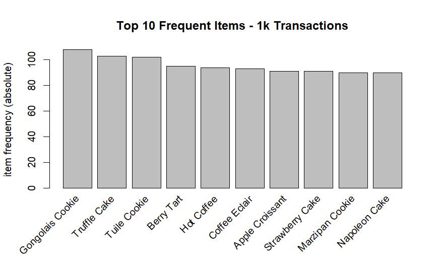

```r
itemFrequencyPlot(tr.1k, topN=10, type="absolute", main="Top 10 Frequent Items - 1k Transactions")
```

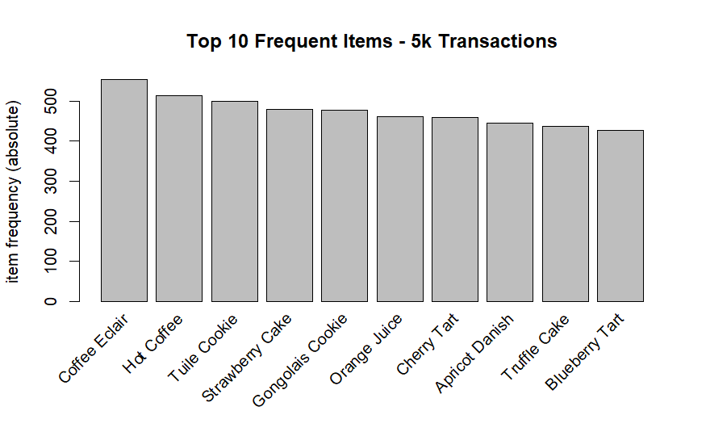

```r
itemFrequencyPlot(tr.5k, topN=10, type="absolute", main="Top 10 Frequent Items - 5k Transactions")
```

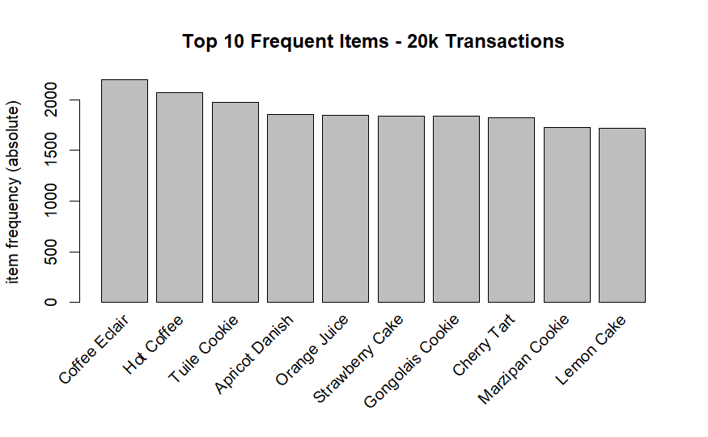

```r
itemFrequencyPlot(tr.20k, topN=10, type="absolute", main="Top 10 Frequent Items - 20k Transactions")
```

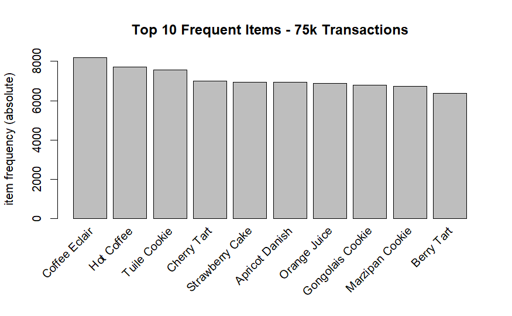

```r
itemFrequencyPlot(tr.75k, topN=10, type="absolute", main="Top 10 Frequent Items - 75k Transactions")
```

```
To reduce overplotting, jitter is added! Use jitter = 0 to prevent jitter.
```

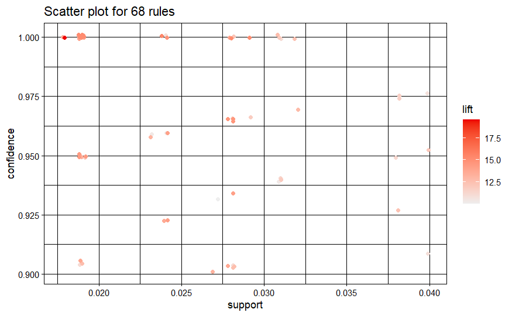

```r
plot(rules_1k, measure=c("support", "confidence"), shading="lift")
```

```
To reduce overplotting, jitter is added! Use jitter = 0 to prevent jitter.
```

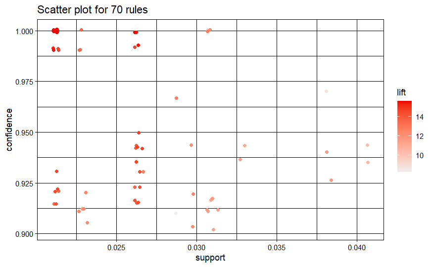

```r
plot(rules_5k, measure=c("support", "confidence"), shading="lift")
```

```
To reduce overplotting, jitter is added! Use jitter = 0 to prevent jitter.
```

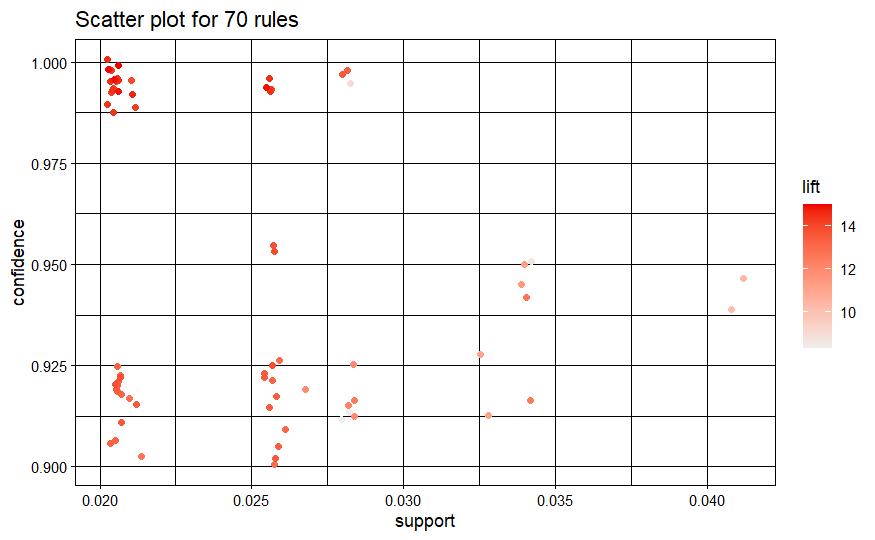

```r
plot(rules_20k, measure=c("support", "confidence"), shading="lift")
```

```
To reduce overplotting, jitter is added! Use jitter = 0 to prevent jitter.
```

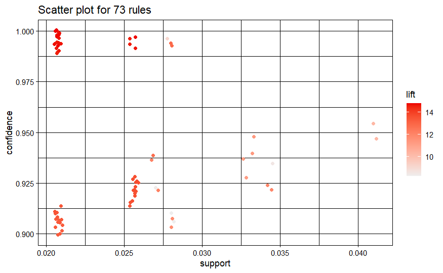

```r
plot(rules_75k, measure=c("support", "confidence"), shading="lift")
```

#### Inventory Management: Understanding item associations also helps in inventory management.

#### Customer Experience Enhancement: By providing a seamless shopping experience where related items are easily accessible, customer satisfaction can be improved. This not only increases sales but also fosters customer loyalty.